# EDA Project

The EDA project in this course has four main parts to it:  
1. Project Proposal 2. Phase 1 3. Phase 2 4. Report This notebook will be used for Project Proposal, Phase 1, and Phase 2. You will have specific questions to answer within this notebook for Project Proposal and Phase 1. You will also continue using this notebook for Phase 2. However, guidance and expectations can be found on Canvas for that assignment. The report is completed outside of this notebook (delivered as a PDF). Detailed instructions for that assignment are provided in Canvas.

**Read this before proceeding:** 1. Review the list of data sets and sources of data to avoid before choosing your data. This list is provided in the instructions for the Project Proposal assignment in Canvas.  
2. It is expected that when you are asked questions requiring typed explanations you are to use a **markdown cell** to type your answers neatly. *Do not provide typed answers to questions as extra comments within your code.* Only provide comments within your code as you normally would, i.e. as needed to explain or remind yourself what each part of the code is doing.

# Project Proposal

The intent of this assignment is for you to share your chosen data file(s) with your instructor and provide general information on your goals for the EDA project.

**Step 1 (2 pts)**: Give a brief *description* of the source(s) of your data and include a *direct link* to your data.

The data is one single csv file: Our complete COVID-19 dataset is a collection of the COVID-19 data maintained by Our World in Data. It is updated daily and includes data on confirmed cases, deaths, hospitalizations, and testing, as well as other variables of potential interest across different countries worldwide.

- Confirmed cases and deaths: our data comes from the COVID-19 Data Repository by the Center for Systems Science and Engineering (CSSE) at Johns Hopkins University (JHU).
- Hospitalizations and intensive care unit (ICU) admissions: our data comes from the European Centre for Disease Prevention and Control (ECDC) for a select number of European countries; the government of the United Kingdom; the COVID Tracking Project for the United States; the COVID-19 Tracker for Canada.
- Testing for COVID-19: this data is collected by the Our World in Data team from official reports. The testing dataset is updated around twice a week.
- Vaccinations against COVID-19: this data is collected by the Our World in Data team from official reports.
- Other variables: this data is collected from a variety of sources (United Nations, World Bank, Global Burden of Disease, Blavatnik School of Government, etc.). More information is available in our codebook.

The data I am using can be found at: https://github.com/owid/covid-19-data/blob/master/public/data/owid-covid-data.csv

**Step 2 (2 pts)**: Briefly explain why you chose this data.

We chose this data because we are very interested in the worldwide COVID-19 pandanmic. Particularly, we would like to investigate some factors that affect number of new cases and number of new deaths of COVID-19, aiming to figure out some strategies that might mitigate the pandemic.

The dataset includes not only COVID epidemiology data such as confirmed cases of COVID-19, deaths attributed to COVID-19 and real-time estimate of the effective reproduction rate of COVID-19, but also plenty of other public health data involving life expectancy, population density, death rate from cardiovascular disease, hospital beds per 1,000 people, diabetes prevalence etc. It is an abundant resource for us to test different dependency hypothesis.

**Step 3 (1 pt)**: Provide a brief overview of your goals for this project.

From all the data available to us in the dataset we are using, we decided to investigate multiples hypotheses. We seek to determine whether:

- Life Expectancy in a given region to correlates to COVID Deaths.
- Population density correlates with new COVID cases
- New COVID cases correlates with cardiovascular related deaths

We plan to demonstrate our findings using data visualization tools.

**Step 4 (1 pt)**: Read the data into this notebook.

```python
# load up modules
import numpy as np
import pandas as pd
```

```python
# set up notebook to display multiple output in one cell
from IPython.core.interactiveshell import InteractiveShell
InteractiveShell.ast_node_interactivity = "all"
```

```python
#Importing Flat Files with pandas
import pandas as pd
filename = 'owid-covid-data.csv'
data = pd.read_csv(filename,
                   header=0, #Row number to use as col names
                   sep=',', #Delimiter to use
                   na_values=[""]) #String to recognize as NA/NaN
```

**Step 5 (1 pt)**: Inspect the data using the **info( )**, **head( )**, and **tail( )** methods.

```python
# TODO: Use the info() method to determine to inspect the variable (column) names, the number of non-null values,
#       and the data types for each variable.
data.info()
# TODO: Use the head() method to inspect the first five (or more) rows of the data
data.head()
# TODO: Use the tail() method to inspect the last five (or more) rows of the data
data.tail()
```

```
<class 'pandas.core.frame.DataFrame'>
RangeIndex: 63572 entries, 0 to 63571
Data columns (total 59 columns):
iso_code                                 63211 non-null object
continent                                62834 non-null object
location                                 63572 non-null object
date                                     63572 non-null object
total_cases                              62978 non-null float64
new_cases                                62970 non-null float64
new_cases_smoothed                       62011 non-null float64
total_deaths                             54354 non-null float64
new_deaths                               54352 non-null float64
new_deaths_smoothed                      62011 non-null float64
total_cases_per_million                  62617 non-null float64
new_cases_per_million                    62609 non-null float64
new_cases_smoothed_per_million           61655 non-null float64
total_deaths_per_million                 54006 non-null float64
new_deaths_per_million                   54004 non-null float64
new_deaths_smoothed_per_million          61655 non-null float64
reproduction_rate                        51295 non-null float64
icu_patients                             7012 non-null float64
icu_patients_per_million                 7012 non-null float64
hosp_patients                            8324 non-null float64
hosp_patients_per_million                8324 non-null float64
weekly_icu_admissions                    693 non-null float64
weekly_icu_admissions_per_million        693 non-null float64
weekly_hosp_admissions                   1061 non-null float64
weekly_hosp_admissions_per_million       1061 non-null float64
total_tests                              29551 non-null float64
new_tests                                29757 non-null float64
total_tests_per_thousand                 29551 non-null float64
new_tests_per_thousand                   29757 non-null float64
new_tests_smoothed                       33539 non-null float64
new_tests_smoothed_per_thousand          33539 non-null float64
positive_rate                            31731 non-null float64
tests_per_case                           31212 non-null float64
tests_units                              34758 non-null object
total_vaccinations                       1205 non-null float64
people_vaccinated                        937 non-null float64
people_fully_vaccinated                  468 non-null float64
```

[output cut: 9 more lines]

```
median_age                               60473 non-null float64
aged_65_older                            59773 non-null float64
aged_70_older                            60131 non-null float64
gdp_per_capita                           60517 non-null float64
extreme_poverty                          41405 non-null float64
cardiovasc_death_rate                    61134 non-null float64
diabetes_prevalence                      61853 non-null float64
female_smokers                           48216 non-null float64
male_smokers                             47555 non-null float64
handwashing_facilities                   30647 non-null float64
hospital_beds_per_thousand               56123 non-null float64
life_expectancy                          62886 non-null float64
human_development_index                  60790 non-null float64
dtypes: float64(54), object(5)
memory usage: 28.6+ MB
```

|  | iso_code | continent | location | date | total_cases | new_cases | new_cases_smoothed | total_deaths | new_deaths | new_deaths_smoothed | ... | gdp_per_capita | extreme_poverty | cardiovasc_death_rate | diabetes_prevalence | female_smokers | male_smokers | handwashing_facilities | hospital_beds_per_thousand | life_expectancy | human_development_index |
| --- | --- | --- | --- | --- | --- | --- | --- | --- | --- | --- | --- | --- | --- | --- | --- | --- | --- | --- | --- | --- | --- |
| 0 | AFG | Asia | Afghanistan | 2020-02-24 | 1.0 | 1.0 | NaN | NaN | NaN | NaN | ... | 1803.987 | NaN | 597.029 | 9.59 | NaN | NaN | 37.746 | 0.5 | 64.83 | 0.498 |
| 1 | AFG | Asia | Afghanistan | 2020-02-25 | 1.0 | 0.0 | NaN | NaN | NaN | NaN | ... | 1803.987 | NaN | 597.029 | 9.59 | NaN | NaN | 37.746 | 0.5 | 64.83 | 0.498 |
| 2 | AFG | Asia | Afghanistan | 2020-02-26 | 1.0 | 0.0 | NaN | NaN | NaN | NaN | ... | 1803.987 | NaN | 597.029 | 9.59 | NaN | NaN | 37.746 | 0.5 | 64.83 | 0.498 |
| 3 | AFG | Asia | Afghanistan | 2020-02-27 | 1.0 | 0.0 | NaN | NaN | NaN | NaN | ... | 1803.987 | NaN | 597.029 | 9.59 | NaN | NaN | 37.746 | 0.5 | 64.83 | 0.498 |
| 4 | AFG | Asia | Afghanistan | 2020-02-28 | 1.0 | 0.0 | NaN | NaN | NaN | NaN | ... | 1803.987 | NaN | 597.029 | 9.59 | NaN | NaN | 37.746 | 0.5 | 64.83 | 0.498 |

5 rows × 59 columns

|  | iso_code | continent | location | date | total_cases | new_cases | new_cases_smoothed | total_deaths | new_deaths | new_deaths_smoothed | ... | gdp_per_capita | extreme_poverty | cardiovasc_death_rate | diabetes_prevalence | female_smokers | male_smokers | handwashing_facilities | hospital_beds_per_thousand | life_expectancy | human_development_index |
| --- | --- | --- | --- | --- | --- | --- | --- | --- | --- | --- | --- | --- | --- | --- | --- | --- | --- | --- | --- | --- | --- |
| 63567 | ZWE | Africa | Zimbabwe | 2021-01-28 | 32646.0 | 342.0 | 371.286 | 1160.0 | 38.0 | 34.714 | ... | 1899.775 | 21.4 | 307.846 | 1.82 | 1.6 | 30.7 | 36.791 | 1.7 | 61.49 | 0.535 |
| 63568 | ZWE | Africa | Zimbabwe | 2021-01-29 | 32952.0 | 306.0 | 347.000 | 1178.0 | 18.0 | 30.857 | ... | 1899.775 | 21.4 | 307.846 | 1.82 | 1.6 | 30.7 | 36.791 | 1.7 | 61.49 | 0.535 |
| 63569 | ZWE | Africa | Zimbabwe | 2021-01-30 | 33273.0 | 321.0 | 323.714 | 1193.0 | 15.0 | 31.286 | ... | 1899.775 | 21.4 | 307.846 | 1.82 | 1.6 | 30.7 | 36.791 | 1.7 | 61.49 | 0.535 |
| 63570 | ZWE | Africa | Zimbabwe | 2021-01-31 | 33388.0 | 115.0 | 295.429 | 1217.0 | 24.0 | 30.286 | ... | 1899.775 | 21.4 | 307.846 | 1.82 | 1.6 | 30.7 | 36.791 | 1.7 | 61.49 | 0.535 |
| 63571 | ZWE | Africa | Zimbabwe | 2021-02-01 | 33548.0 | 160.0 | 271.714 | 1234.0 | 17.0 | 22.714 | ... | 1899.775 | 21.4 | 307.846 | 1.82 | 1.6 | 30.7 | 36.791 | 1.7 | 61.49 | 0.535 |

5 rows × 59 columns

```python
for i in range(len(data)):
    d = data.iloc[i]["date"]
    if type(d) != str:
        print(d)
```

```python
for i in range(len(data)):
    d = data.iloc[i]["location"]
    if type(d) != str:
        print(d)
```

**STOP HERE for your Project Proposal assignment. Submit your (1) original data file(s) along with (2) the completed notebook up to this point, and (3) the html file for grading and approval.**

**Instructor Feedback and Approval (3 pts)**: Your instructor will provide feedback in either the cell below this or via Canvas. You can expect one of the following point values for this portion. **3 pts** - if your project goals and data set are both approved.  
**2 pts** - if your data set is approved but changes to your project goals (Step 3) are needed.  
**1 pt** - if your project goals are approved but your data set is not approved.  
**0 pts** - if neither your data set nor your project goals are approved.  
*As needed, follow your instructor's feeback and guidance to get on track for the remaining portions of the EDA project.*

# EDA Phase 1

The overall goal of this assignment is to take all necessary steps to inspect the quality of your data and prepare the data according to your needs. For information and resources on the process of Exploratory Data Analysis (EDA), you should explore the **EDA Project Resources Module** in Canvas. Once you’ve read through the information provided in that module and have a comfortable understanding of EDA using Python, complete steps 6 through 10 listed below to satisfy the requirements for your EDA Phase 1 assignment. **Remember to convert code cells provided to markdown cells for any typed responses to questions.**

**Step 6 (2 pts)**: Begin by elaborating in more detail from the previous assignment on why you chose this data?  
1. Explain what you hope to learn from this data. 2. Do you have a hunch about what this data will reveal? (The answer to this question will be used in the Introduction section of your EDA report.)

1. We wish to examine COVID data and recognize various trends associated with the number of cases and deaths from the pandemic. We hope to learn which factors effect the amount of COVID death/cases worldwide. Specifically, the factors were are interested in include life expectancy, population density, and cardiovascular related deaths.
2. We believe that the data will reveal that:
   - Life Expectancy in a given region are negatively correlated to COVID Deaths.
   - Population density are positively correlated with new COVID cases.
   - New COVID cases are positively correlated with cardiovascular related deaths.

**Step 7 (2 pts)**: Discuss the popluation and the sample:  
1. What is the population being represented by the data you’ve chosen? 2. What is the total sample size?

**Step 8 (2 pts)**: Describe how the data was collected. For example, is this a random sample? Are sampling weights used with the data?

Data was collected by government,national, and subnational agencies across the world. Cases were reported to the Center of Systems Sciences and Engineering (CSSE) at Johns Hopkins University. There were no sampling weights used in this data.

**Step 9 (4 pts)**: In the Project Proposal assignment you used the info( ) method to inspect the variables, their data types, and the number of non-null values. Using that information as a guide, provide definitions of each of your variables and their corresponding data types, i.e. a data dictionary. Also indicate which variables will be used for your purposes.

The variables of interest include: Date, Location, Life Expentancy, Total Deaths, Population Density, Total Cases, New Cases, and Cardiovascular related deaths. The following provides an in depth description of each variable.

Date

- Description:Date of observation
- Variable name: date
- 63572 values
- object type: object string
- Purpose: will be used to for observing progression of cases/deaths

Location

- Description: Country where COVID case(s) are observed
- Variable name: location
- 63572 values
- object type: object string
- Purpose: will be used to compare COVID cases/deaths amongst diffeent countries

Total Cases

- Description: Total confirmed cases of COVID-19
- Varaible name: total_cases
- 62978 values
- object type: float64
- Purpose: will be used in correlations

Cardiovascular Related Deaths

- Description: Death rate from cardiovascular disease in 2017 (annual number of deaths per 100,000 people)
- Variable name: cardiovasc_death_rate
- 61134 values
- object type: float64
- Purpose: will be used in correlation with New COVID cases

Population Density

- Decription: Number of people divided by land area, measured in square kilometers, most recent year available
- Variable name: population_density
- 61875 values
- Object Type: float64
- Purpose: will be used in correlation with new COVID cases

Life Expectancy

- Description: Life expectancy at birth in 2019
- Variable name: life_expectancy
- 62886 values
- Object type: float64
- Purpose: will be used in correlation with Total COVID deaths

New Cases

- Description: New confirmed cases of COVID-19
- Variable name: new_cases
- 62970 values
- Object type: float64
- Purpose: will be used in correlation with Population Density and Cardiovascular Related Deaths

Total Deaths

- Description: Total deaths attributed to COVID-19
- Variable name: total_deaths
- 54354 values
- Object Type: float64
- Purpose: will be used in correlation with Life Expectancy

**Step 10 (10 pts)**: For full credit in this problem you'll want to *take all necessary steps to report on the quality of the data* and *clean the data accordingly*. Some things to consider while doing this are listed below. **Depending on your data and goals, there may be additional steps needed than those listed here.** 1. Are there rows with missing or inconsistent values? If so, eliminate those rows from your data where appropriate. 2. Are there any outliers or duplicate rows? If so, eliminate those rows from your data where appropriate. At each stage of cleaning the data, state how many rows were eliminated. 3. Are you using all columns (variables) in the data? If not, are you eliminating those columns? 4. Consider some type of visual display such as a boxplot to determine any outliers. Do any outliers need removed? If so, how many were removed? At each stage of cleaning the data, state how many rows were eliminated. *It is good practice to get the shape of the data before and after each step in cleaning the data and add typed explanations (in separate markdown cells) of the steps taken to clean the data.*

Include the rest of your work below and insert cells where needed.

1. Yes, there are missing values throughout the dataset. There were also accumulative values for the World. We do not want these. First, 377 rows were dropped for the World location. Next, 11,760 rows with NaN values were dropped.
2. There are no duplicates. No rows were eliminated
3. No, we are not using all columns. The variables of interest listed above will be kept and the following columns were eliminated:

   ```
    iso_code, continent,new_cases_smoothed,new_deaths,new_deaths_smoothed,total_cases_per_million,new_cases_per_million, new_cases_smoothed_per_million,total_deaths_per_million,new_deaths_per_million,new_deaths_smoothed_per_million, reproduction_rate, icu_patients,icu_patients_per_million, hosp_patients, hosp_patients_per_million,weekly_icu_admissions, weekly_icu_admissions_per_million, weekly_hosp_admissions, weekly_hosp_admissions_per_million, total_tests, new_tests, total_tests_per_thousand, new_tests_per_thousand, new_tests_smoothed, new_tests_smoothed_per_thousand, positive_rate, tests_per_case, tests_units, total_vaccinations, people_vaccinated, people_fully_vaccinated, new_vaccinations, new_vaccinations_smoothed,total_vaccinations_per_hundred, people_vaccinated_per_hundred, people_fully_vaccinated_per_hundred, new_vaccinations_smoothed_per_million, stringency_index, population, median_age, aged_65_older, aged_70_older, gdp_per_capita, extreme_poverty,diabetes_prevalence, female_smokers, male_smokers, handwashing_facilities, hospital_beds_per_thousand, human_development_index
   ```

Cleaning can be found below:

```python
#A dataframe will be constructed with the variables of interest
clean= data[["location","date", "total_cases","cardiovasc_death_rate","population_density","life_expectancy","new_cases","total_deaths"]]
clean.head()
clean.shape
```

|  | location | date | total_cases | cardiovasc_death_rate | population_density | life_expectancy | new_cases | total_deaths |
| --- | --- | --- | --- | --- | --- | --- | --- | --- |
| 0 | Afghanistan | 2020-02-24 | 1.0 | 597.029 | 54.422 | 64.83 | 1.0 | NaN |
| 1 | Afghanistan | 2020-02-25 | 1.0 | 597.029 | 54.422 | 64.83 | 0.0 | NaN |
| 2 | Afghanistan | 2020-02-26 | 1.0 | 597.029 | 54.422 | 64.83 | 0.0 | NaN |
| 3 | Afghanistan | 2020-02-27 | 1.0 | 597.029 | 54.422 | 64.83 | 0.0 | NaN |
| 4 | Afghanistan | 2020-02-28 | 1.0 | 597.029 | 54.422 | 64.83 | 0.0 | NaN |

```
(63572, 8)
```

```python
#Count of all the locations
pd.set_option('display.max_rows', None)
test=pd.DataFrame(clean.location.value_counts())
test.max
```

```
<bound method DataFrame.max of                                   location
Argentina                              398
Mexico                                 398
Thailand                               395
Taiwan                                 383
South Korea                            378
United States                          377
Japan                                  377
World                                  377
China                                  377
Singapore                              376
Vietnam                                376
France                                 375
Switzerland                            375
Nepal                                  374
Malaysia                               374
Canada                                 373
Australia                              373
Cambodia                               372
Germany                                372
Sri Lanka                              372
United Arab Emirates                   370
Finland                                370
Fiji                                   369
India                                  369
Philippines                            369
Italy                                  368
Russia                                 368
United Kingdom                         368
Spain                                  367
Estonia                                367
Slovenia                               366
Denmark                                366
Belgium                                364
Malta                                  362
Morocco                                361
South Africa                           361
Sweden                                 361
International                          361
Egypt                                  354
```

[output cut: 139 more lines]

```
Botswana                               309
Burundi                                308
Sierra Leone                           308
South Sudan                            303
Sao Tome and Principe                  302
Yemen                                  298
Tajikistan                             278
Comoros                                278
Lesotho                                265
Solomon Islands                        113
Marshall Islands                        97
Hong Kong                               90
Vanuatu                                 84
Samoa                                   76
Micronesia (country)                    12>
```

```python
#There are World values in the data set
#How many World values?
clean.loc[clean['location']=='World'].shape
```

```
(377, 8)
```

```python
#Lets remove data for World location
test2=clean.drop(clean.loc[clean['location']=='World'].index)
test2.location.value_counts()
test2.shape
```

```
Argentina                           398
Mexico                              398
Thailand                            395
Taiwan                              383
South Korea                         378
United States                       377
Japan                               377
China                               377
Vietnam                             376
Singapore                           376
France                              375
Switzerland                         375
Malaysia                            374
Nepal                               374
Canada                              373
Australia                           373
Sri Lanka                           372
Cambodia                            372
Germany                             372
United Arab Emirates                370
Finland                             370
Philippines                         369
Fiji                                369
India                               369
Italy                               368
Russia                              368
United Kingdom                      368
Estonia                             367
Spain                               367
Slovenia                            366
Denmark                             366
Belgium                             364
Malta                               362
Sweden                              361
South Africa                        361
Morocco                             361
International                       361
Egypt                               354
Guatemala                           351
Iran                                349
```

[output cut: 138 more lines]

```
Burundi                             308
Sierra Leone                        308
South Sudan                         303
Sao Tome and Principe               302
Yemen                               298
Tajikistan                          278
Comoros                             278
Lesotho                             265
Solomon Islands                     113
Marshall Islands                     97
Hong Kong                            90
Vanuatu                              84
Samoa                                76
Micronesia (country)                 12
Name: location, dtype: int64
```

```
(63195, 8)
```

```python
#There should be no world values after drop
test2.loc[clean['location']=='World'].shape
```

```
(0, 8)
```

```python
#Next lets drop NaN values
clean_drop= test2.dropna()
clean_drop.head()
clean_drop.shape
```

|  | location | date | total_cases | cardiovasc_death_rate | population_density | life_expectancy | new_cases | total_deaths |
| --- | --- | --- | --- | --- | --- | --- | --- | --- |
| 27 | Afghanistan | 2020-03-22 | 34.0 | 597.029 | 54.422 | 64.83 | 4.0 | 1.0 |
| 28 | Afghanistan | 2020-03-23 | 41.0 | 597.029 | 54.422 | 64.83 | 7.0 | 1.0 |
| 29 | Afghanistan | 2020-03-24 | 43.0 | 597.029 | 54.422 | 64.83 | 2.0 | 1.0 |
| 30 | Afghanistan | 2020-03-25 | 76.0 | 597.029 | 54.422 | 64.83 | 33.0 | 2.0 |
| 31 | Afghanistan | 2020-03-26 | 80.0 | 597.029 | 54.422 | 64.83 | 4.0 | 3.0 |

```
(51435, 8)
```

```python
#How many NaN values were dropped?  Let's look at the change in shape.

print(63195-51435, "rows with NaN values were dropped")
```

```
11760 rows with NaN values were dropped
```

```python
#Are there any duplicates?
clean_drop.duplicated().any()
```

```
False
```

```python
#Lets make a new dataframe that only includes the last date (FEB 1st).  This will be the true values
#of total cases and total deaths
clean_drop_total_cases=clean_drop[clean_drop.date=="2021-02-01"]
clean_drop_total_cases.head()
clean_drop_total_cases.shape
```

|  | location | date | total_cases | cardiovasc_death_rate | population_density | life_expectancy | new_cases | total_deaths |
| --- | --- | --- | --- | --- | --- | --- | --- | --- |
| 343 | Afghanistan | 2021-02-01 | 55059.0 | 597.029 | 54.422 | 64.83 | 36.0 | 2404.0 |
| 673 | Albania | 2021-02-01 | 78992.0 | 304.195 | 104.871 | 78.57 | 865.0 | 1393.0 |
| 1016 | Algeria | 2021-02-01 | 107578.0 | 278.364 | 17.348 | 76.88 | 239.0 | 2894.0 |
| 1353 | Andorra | 2021-02-01 | 9972.0 | 109.135 | 163.755 | 83.73 | 35.0 | 101.0 |
| 1672 | Angola | 2021-02-01 | 19829.0 | 276.045 | 23.890 | 61.15 | 33.0 | 466.0 |

```
(171, 8)
```

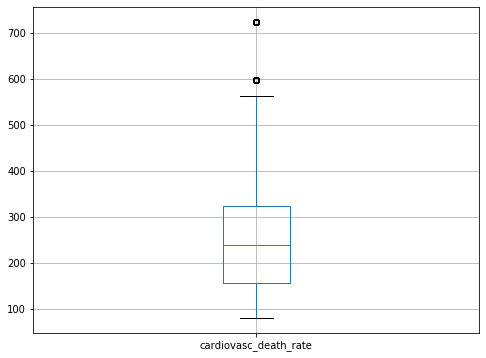

```python
#We will use boxplots for finding potential outliers
#cardiovascular_death_rate boxplot
clean_drop.boxplot(column='cardiovasc_death_rate',figsize=(8,6))
```

```python
#cardiovascular_death_rate outliers
clean_drop[clean_drop['cardiovasc_death_rate']>550]
```

|  | location | date | total_cases | cardiovasc_death_rate | population_density | life_expectancy | new_cases | total_deaths |
| --- | --- | --- | --- | --- | --- | --- | --- | --- |
| 27 | Afghanistan | 2020-03-22 | 34.0 | 597.029 | 54.422 | 64.83 | 4.0 | 1.0 |
| 28 | Afghanistan | 2020-03-23 | 41.0 | 597.029 | 54.422 | 64.83 | 7.0 | 1.0 |
| 29 | Afghanistan | 2020-03-24 | 43.0 | 597.029 | 54.422 | 64.83 | 2.0 | 1.0 |
| 30 | Afghanistan | 2020-03-25 | 76.0 | 597.029 | 54.422 | 64.83 | 33.0 | 2.0 |
| 31 | Afghanistan | 2020-03-26 | 80.0 | 597.029 | 54.422 | 64.83 | 4.0 | 3.0 |
| 32 | Afghanistan | 2020-03-27 | 91.0 | 597.029 | 54.422 | 64.83 | 11.0 | 3.0 |
| 33 | Afghanistan | 2020-03-28 | 107.0 | 597.029 | 54.422 | 64.83 | 16.0 | 4.0 |
| 34 | Afghanistan | 2020-03-29 | 118.0 | 597.029 | 54.422 | 64.83 | 11.0 | 4.0 |
| 35 | Afghanistan | 2020-03-30 | 146.0 | 597.029 | 54.422 | 64.83 | 28.0 | 4.0 |
| 36 | Afghanistan | 2020-03-31 | 175.0 | 597.029 | 54.422 | 64.83 | 29.0 | 4.0 |
| 37 | Afghanistan | 2020-04-01 | 197.0 | 597.029 | 54.422 | 64.83 | 22.0 | 4.0 |
| 38 | Afghanistan | 2020-04-02 | 240.0 | 597.029 | 54.422 | 64.83 | 43.0 | 4.0 |
| 39 | Afghanistan | 2020-04-03 | 275.0 | 597.029 | 54.422 | 64.83 | 35.0 | 8.0 |
| 40 | Afghanistan | 2020-04-04 | 300.0 | 597.029 | 54.422 | 64.83 | 25.0 | 10.0 |
| 41 | Afghanistan | 2020-04-05 | 338.0 | 597.029 | 54.422 | 64.83 | 38.0 | 12.0 |
| 42 | Afghanistan | 2020-04-06 | 368.0 | 597.029 | 54.422 | 64.83 | 30.0 | 15.0 |
| 43 | Afghanistan | 2020-04-07 | 424.0 | 597.029 | 54.422 | 64.83 | 56.0 | 16.0 |
| 44 | Afghanistan | 2020-04-08 | 445.0 | 597.029 | 54.422 | 64.83 | 21.0 | 16.0 |
| 45 | Afghanistan | 2020-04-09 | 485.0 | 597.029 | 54.422 | 64.83 | 40.0 | 17.0 |
| 46 | Afghanistan | 2020-04-10 | 532.0 | 597.029 | 54.422 | 64.83 | 47.0 | 18.0 |
| 47 | Afghanistan | 2020-04-11 | 556.0 | 597.029 | 54.422 | 64.83 | 24.0 | 18.0 |
| 48 | Afghanistan | 2020-04-12 | 608.0 | 597.029 | 54.422 | 64.83 | 52.0 | 19.0 |
| 49 | Afghanistan | 2020-04-13 | 666.0 | 597.029 | 54.422 | 64.83 | 58.0 | 22.0 |
| 50 | Afghanistan | 2020-04-14 | 715.0 | 597.029 | 54.422 | 64.83 | 49.0 | 23.0 |
| 51 | Afghanistan | 2020-04-15 | 785.0 | 597.029 | 54.422 | 64.83 | 70.0 | 29.0 |
| 52 | Afghanistan | 2020-04-16 | 841.0 | 597.029 | 54.422 | 64.83 | 56.0 | 30.0 |
| 53 | Afghanistan | 2020-04-17 | 907.0 | 597.029 | 54.422 | 64.83 | 66.0 | 30.0 |
| 54 | Afghanistan | 2020-04-18 | 934.0 | 597.029 | 54.422 | 64.83 | 27.0 | 30.0 |
| 55 | Afghanistan | 2020-04-19 | 997.0 | 597.029 | 54.422 | 64.83 | 63.0 | 33.0 |
| 56 | Afghanistan | 2020-04-20 | 1027.0 | 597.029 | 54.422 | 64.83 | 30.0 | 36.0 |

[output cut: 1113 more lines]

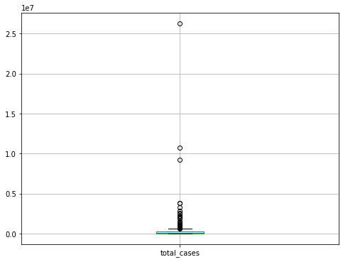

```python
#total_cases boxplot
clean_drop_total_cases.boxplot(column='total_cases', figsize=(8,6))
```

```python
#total_cases outliers
clean_drop_total_cases[clean_drop_total_cases['total_cases']>5000000]
```

|  | location | date | total_cases | cardiovasc_death_rate | population_density | life_expectancy | new_cases | total_deaths |
| --- | --- | --- | --- | --- | --- | --- | --- | --- |
| 8102 | Brazil | 2021-02-01 | 9229322.0 | 177.961 | 25.040 | 75.88 | 24591.0 | 225099.0 |
| 26006 | India | 2021-02-01 | 10766245.0 | 282.280 | 450.419 | 69.66 | 8635.0 | 154486.0 |
| 60488 | United States | 2021-02-01 | 26321120.0 | 151.089 | 35.608 | 78.86 | 134339.0 | 443355.0 |

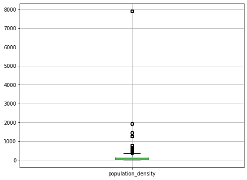

```python
#population_density boxplot
clean_drop.boxplot(column='population_density',figsize=(8,6))
```

```python
#population density outliers
clean_drop[clean_drop['population_density']>7000]
```

|  | location | date | total_cases | cardiovasc_death_rate | population_density | life_expectancy | new_cases | total_deaths |
| --- | --- | --- | --- | --- | --- | --- | --- | --- |
| 50762 | Singapore | 2020-03-21 | 432.0 | 92.243 | 7915.731 | 83.62 | 47.0 | 2.0 |
| 50763 | Singapore | 2020-03-22 | 455.0 | 92.243 | 7915.731 | 83.62 | 23.0 | 2.0 |
| 50764 | Singapore | 2020-03-23 | 509.0 | 92.243 | 7915.731 | 83.62 | 54.0 | 2.0 |
| 50765 | Singapore | 2020-03-24 | 558.0 | 92.243 | 7915.731 | 83.62 | 49.0 | 2.0 |
| 50766 | Singapore | 2020-03-25 | 631.0 | 92.243 | 7915.731 | 83.62 | 73.0 | 2.0 |
| 50767 | Singapore | 2020-03-26 | 683.0 | 92.243 | 7915.731 | 83.62 | 52.0 | 2.0 |
| 50768 | Singapore | 2020-03-27 | 732.0 | 92.243 | 7915.731 | 83.62 | 49.0 | 2.0 |
| 50769 | Singapore | 2020-03-28 | 802.0 | 92.243 | 7915.731 | 83.62 | 70.0 | 2.0 |
| 50770 | Singapore | 2020-03-29 | 844.0 | 92.243 | 7915.731 | 83.62 | 42.0 | 3.0 |
| 50771 | Singapore | 2020-03-30 | 879.0 | 92.243 | 7915.731 | 83.62 | 35.0 | 3.0 |
| 50772 | Singapore | 2020-03-31 | 926.0 | 92.243 | 7915.731 | 83.62 | 47.0 | 3.0 |
| 50773 | Singapore | 2020-04-01 | 1000.0 | 92.243 | 7915.731 | 83.62 | 74.0 | 3.0 |
| 50774 | Singapore | 2020-04-02 | 1049.0 | 92.243 | 7915.731 | 83.62 | 49.0 | 4.0 |
| 50775 | Singapore | 2020-04-03 | 1114.0 | 92.243 | 7915.731 | 83.62 | 65.0 | 5.0 |
| 50776 | Singapore | 2020-04-04 | 1189.0 | 92.243 | 7915.731 | 83.62 | 75.0 | 6.0 |
| 50777 | Singapore | 2020-04-05 | 1309.0 | 92.243 | 7915.731 | 83.62 | 120.0 | 6.0 |
| 50778 | Singapore | 2020-04-06 | 1375.0 | 92.243 | 7915.731 | 83.62 | 66.0 | 6.0 |
| 50779 | Singapore | 2020-04-07 | 1481.0 | 92.243 | 7915.731 | 83.62 | 106.0 | 6.0 |
| 50780 | Singapore | 2020-04-08 | 1623.0 | 92.243 | 7915.731 | 83.62 | 142.0 | 6.0 |
| 50781 | Singapore | 2020-04-09 | 1910.0 | 92.243 | 7915.731 | 83.62 | 287.0 | 6.0 |
| 50782 | Singapore | 2020-04-10 | 2108.0 | 92.243 | 7915.731 | 83.62 | 198.0 | 7.0 |
| 50783 | Singapore | 2020-04-11 | 2299.0 | 92.243 | 7915.731 | 83.62 | 191.0 | 8.0 |
| 50784 | Singapore | 2020-04-12 | 2532.0 | 92.243 | 7915.731 | 83.62 | 233.0 | 8.0 |
| 50785 | Singapore | 2020-04-13 | 2918.0 | 92.243 | 7915.731 | 83.62 | 386.0 | 9.0 |
| 50786 | Singapore | 2020-04-14 | 3252.0 | 92.243 | 7915.731 | 83.62 | 334.0 | 10.0 |
| 50787 | Singapore | 2020-04-15 | 3699.0 | 92.243 | 7915.731 | 83.62 | 447.0 | 10.0 |
| 50788 | Singapore | 2020-04-16 | 4427.0 | 92.243 | 7915.731 | 83.62 | 728.0 | 10.0 |
| 50789 | Singapore | 2020-04-17 | 5050.0 | 92.243 | 7915.731 | 83.62 | 623.0 | 11.0 |
| 50790 | Singapore | 2020-04-18 | 5992.0 | 92.243 | 7915.731 | 83.62 | 942.0 | 11.0 |
| 50791 | Singapore | 2020-04-19 | 6588.0 | 92.243 | 7915.731 | 83.62 | 596.0 | 11.0 |

[output cut: 288 more lines]

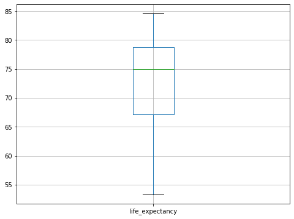

```python
#life_expectancy boxplot
clean_drop.boxplot(column='life_expectancy',figsize=(8,6))
```

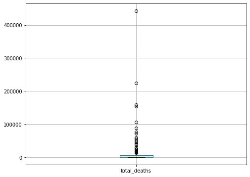

```python
#total_deaths boxplot
clean_drop_total_cases.boxplot(column='total_deaths',figsize=(8,6))
```

```python
#total_deaths outliers
clean_drop_total_cases[clean_drop_total_cases['total_deaths']>200000]
```

|  | location | date | total_cases | cardiovasc_death_rate | population_density | life_expectancy | new_cases | total_deaths |
| --- | --- | --- | --- | --- | --- | --- | --- | --- |
| 8102 | Brazil | 2021-02-01 | 9229322.0 | 177.961 | 25.040 | 75.88 | 24591.0 | 225099.0 |
| 60488 | United States | 2021-02-01 | 26321120.0 | 151.089 | 35.608 | 78.86 | 134339.0 | 443355.0 |

```python
clean_drop.to_csv('covid_g4_all.csv',index=False)
```

```python
clean_drop_total_cases.to_csv('covid_g4_feb1.csv',index=False)
```

**STOP HERE for your EDA Phase 1 assignment. Submit your *cleaned* data file along with the completed notebook up to this point for grading.**

# EDA Phase 2

All of your work for the EDA Phase 2 assignment will begin below here. Refer to the detailed instructions and expectations for this assignment in Canvas.

```python
import pandas as pd # panda's nickname is pd
import numpy as np # numpy as np
from pandas import DataFrame, Series # for convenience
import csv
import seaborn as sns
import matplotlib.pyplot as plt
import sklearn.linear_model
import matplotlib as mpl
%matplotlib inline

# set up notebook to display multiple output in one cell
from IPython.core.interactiveshell import InteractiveShell
InteractiveShell.ast_node_interactivity = "all"

from sklearn.linear_model import LinearRegression, Ridge, Lasso, ElasticNet
from sklearn.metrics import mean_squared_error, r2_score
from math import sqrt
from scipy import stats
```

```python
filename = 'covid_g4_all.csv'
covid_all = pd.read_csv(filename,
                   header=0, #Row number to use as col names
                   sep=',', #Delimiter to use
                   na_values=[""]) #String to recognize as NA/NaN
```

```python
filename = 'covid_g4_feb1.csv'
covid_sum = pd.read_csv(filename,
                   header=0, #Row number to use as col names
                   sep=',', #Delimiter to use
                   na_values=[""]) #String to recognize as NA/NaN
```

```python
covid_all.head()
```

|  | location | date | total_cases | cardiovasc_death_rate | population_density | life_expectancy | new_cases | total_deaths |
| --- | --- | --- | --- | --- | --- | --- | --- | --- |
| 0 | Afghanistan | 2020-03-22 | 34.0 | 597.029 | 54.422 | 64.83 | 4.0 | 1.0 |
| 1 | Afghanistan | 2020-03-23 | 41.0 | 597.029 | 54.422 | 64.83 | 7.0 | 1.0 |
| 2 | Afghanistan | 2020-03-24 | 43.0 | 597.029 | 54.422 | 64.83 | 2.0 | 1.0 |
| 3 | Afghanistan | 2020-03-25 | 76.0 | 597.029 | 54.422 | 64.83 | 33.0 | 2.0 |
| 4 | Afghanistan | 2020-03-26 | 80.0 | 597.029 | 54.422 | 64.83 | 4.0 | 3.0 |

```python
covid_all.info()
```

```
<class 'pandas.core.frame.DataFrame'>
RangeIndex: 51435 entries, 0 to 51434
Data columns (total 8 columns):
location                 51435 non-null object
date                     51435 non-null object
total_cases              51435 non-null float64
cardiovasc_death_rate    51435 non-null float64
population_density       51435 non-null float64
life_expectancy          51435 non-null float64
new_cases                51435 non-null float64
total_deaths             51435 non-null float64
dtypes: float64(6), object(2)
memory usage: 3.1+ MB
```

```python
covid_sum.head()
```

|  | location | date | total_cases | cardiovasc_death_rate | population_density | life_expectancy | new_cases | total_deaths |
| --- | --- | --- | --- | --- | --- | --- | --- | --- |
| 0 | Afghanistan | 2021-02-01 | 55059.0 | 597.029 | 54.422 | 64.83 | 36.0 | 2404.0 |
| 1 | Albania | 2021-02-01 | 78992.0 | 304.195 | 104.871 | 78.57 | 865.0 | 1393.0 |
| 2 | Algeria | 2021-02-01 | 107578.0 | 278.364 | 17.348 | 76.88 | 239.0 | 2894.0 |
| 3 | Andorra | 2021-02-01 | 9972.0 | 109.135 | 163.755 | 83.73 | 35.0 | 101.0 |
| 4 | Angola | 2021-02-01 | 19829.0 | 276.045 | 23.890 | 61.15 | 33.0 | 466.0 |

```python
covid_sum.info()
```

```
<class 'pandas.core.frame.DataFrame'>
RangeIndex: 171 entries, 0 to 170
Data columns (total 8 columns):
location                 171 non-null object
date                     171 non-null object
total_cases              171 non-null float64
cardiovasc_death_rate    171 non-null float64
population_density       171 non-null float64
life_expectancy          171 non-null float64
new_cases                171 non-null float64
total_deaths             171 non-null float64
dtypes: float64(6), object(2)
memory usage: 10.8+ KB
```

```python
covid_sum.describe()
```

|  | total_cases | cardiovasc_death_rate | population_density | life_expectancy | new_cases | total_deaths |
| --- | --- | --- | --- | --- | --- | --- |
| count | 1.710000e+02 | 171.000000 | 171.000000 | 171.00000 | 171.000000 | 171.000000 |
| mean | 6.009260e+05 | 257.709848 | 206.527556 | 72.64538 | 2614.403509 | 13005.192982 |
| std | 2.338308e+06 | 118.290794 | 646.530265 | 7.60910 | 12212.492967 | 43706.518672 |
| min | 5.500000e+01 | 79.370000 | 1.980000 | 53.28000 | 0.000000 | 1.000000 |
| 25% | 1.086000e+04 | 169.380500 | 36.066000 | 66.87000 | 18.000000 | 152.000000 |
| 50% | 7.875500e+04 | 242.648000 | 81.721000 | 74.30000 | 239.000000 | 959.000000 |
| 75% | 2.647345e+05 | 324.204500 | 205.144500 | 77.94000 | 1016.000000 | 5484.500000 |
| max | 2.632112e+07 | 724.417000 | 7915.731000 | 84.63000 | 134339.000000 | 443355.000000 |

## Seaborn pairpots

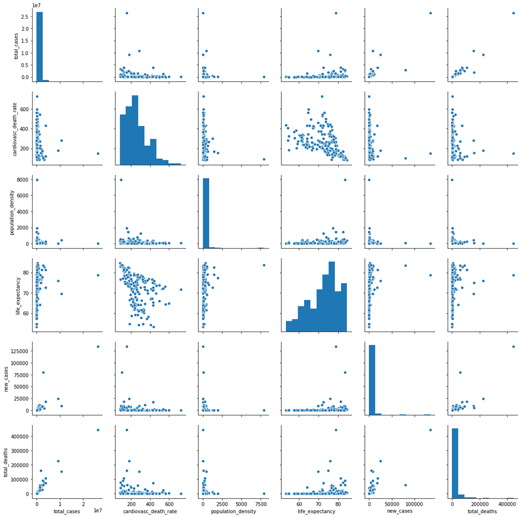

```python
# pair plots
sns.pairplot(covid_sum)
```

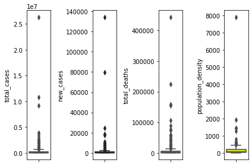

```python
# Create the figure with the subplot
f, axes = plt.subplots(1,4)
plt.figsize=(10,20)

sns.boxplot(y=covid_sum['total_cases'], orient = 'v', color = 'red', ax = axes[0])
sns.boxplot(y=covid_sum['new_cases'], orient = 'v', color = 'green', ax = axes[1])
sns.boxplot(y=covid_sum['total_deaths'], orient = 'v', color = 'grey', ax = axes[2])
sns.boxplot(y=covid_sum['population_density'], orient = 'v', color = 'yellow', ax = axes[3])

plt.tight_layout()
```

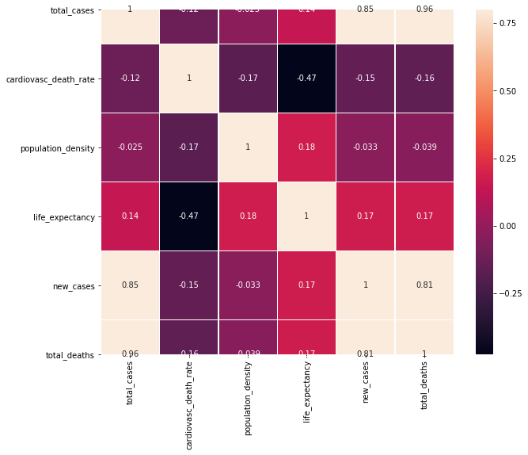

```python
# set up correlation matrixs
corrmat=covid_sum.corr()
f,ax=plt.subplots(figsize=(10,8))
sns.heatmap(corrmat,vmax=0.8, annot=True,linewidths=0.5)
```

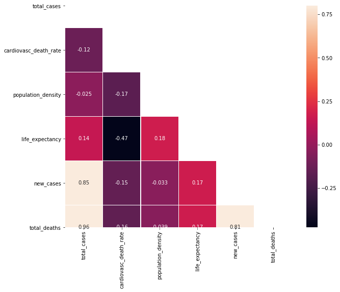

```python
# show only half of matrix
corrmat=covid_sum.corr()
mask = np.triu(np.ones_like(corrmat, dtype=bool))

f,ax=plt.subplots(figsize=(10,8))
sns.heatmap(corrmat,vmax=0.8, mask = mask, annot=True,linewidths=0.5)
```

## Correlation results

The highest correlation is the correlation between total cases and total deaths (0.96). Other than the correlations between COVID cases/deaths, the most correlated two variables are life expectancy and cardiovascular related deaths (-0.47). It is reasonable that the countries with less life expectancy have higher cardiovascular related death rate because the countries with less life expectancy were expected to have poorer medical resources.

After looking at relationships we are interested in, we can see that:

- There is a weak positive correlation between life expectancy and total COVID deaths (0.17). One would expect higher life expectancy would be negatively associated with total COVID deaths.
- There is almost no correlation between population density and new COVID cases (-0.033).
- There is low negative correlation between new COVID cases and cardiovascular related deaths (-0.15). We would expect new COVID cases are positively correlated with cardiovascular related deaths.

## Linear Relationship Results

We further investigate if there are linear relationships between variables we are interested in by scatterplots and regression models.

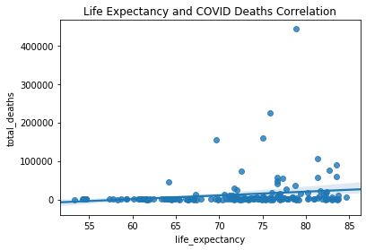

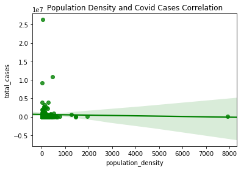

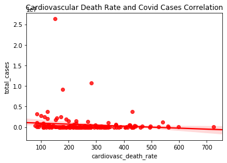

```python
sns.regplot(x="life_expectancy", y="total_deaths", data=covid_sum)
plt.title("Life Expectancy and COVID Deaths Correlation")
plt.show()

sns.regplot(x="population_density", y="total_cases", color='green', data=covid_sum)
plt.title("Population Density and Covid Cases Correlation")
plt.show()

sns.regplot(x="cardiovasc_death_rate", y="total_cases", color='red', data=covid_sum)
plt.title("Cardiovascular Death Rate and Covid Cases Correlation")
plt.show()
```

```python
x = covid_sum['life_expectancy']
y = covid_sum['total_deaths']
slope, intercept, r_value, p_value, std_err = stats.linregress(x,y)
print("Life Expectancy and COVID Deaths Correlation")
print ("Slope:", slope)
print("R^2 Value:", r_value**2)
print()

x = covid_sum['population_density']
y = covid_sum['total_cases']
slope, intercept, r_value, p_value, std_err = stats.linregress(x,y)
print("Population Density and Covid Cases Correlation")
print ("Slope:", slope)
print("R^2 Value:", r_value**2)
print()

x = covid_sum['cardiovasc_death_rate']
y = covid_sum['total_cases']
slope, intercept, r_value, p_value, std_err = stats.linregress(x,y)
print("Cardiovascular Death Rate and Covid Cases Correlation")
print ("Slope:", slope)
print("R^2 Value:", r_value**2)
print()
```

```
Life Expectancy and COVID Deaths Correlation
Slope: 976.9306555220825
R^2 Value: 0.028926882793745848

Population Density and Covid Cases Correlation
Slope: -91.74369229447981
R^2 Value: 0.0006434677025422435

Cardiovascular Death Rate and Covid Cases Correlation
Slope: -2427.1893434655544
R^2 Value: 0.015076683378477871
```

The slopes of the scatterplots tell us that:

- As life expectancy of a country increases, COVID deaths increase.
- As population density increases, total cases decrease.
- As cardiovascular death rate increases, total cases decrease.

## Linear Relationship Results after excluding outliers

There may be some potential outliers in our data that we can further exclude for total deaths, population density and new cases. We will then investigate linear relationships between variables of interests by scatterplots and regression models.

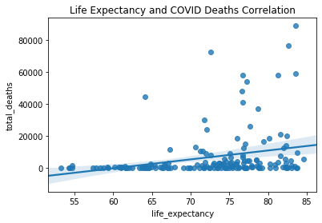

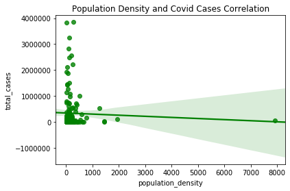

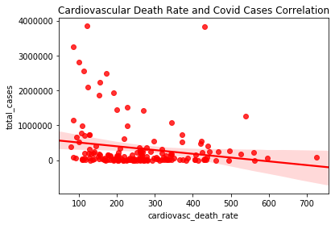

```python
sns.regplot(x="life_expectancy", y="total_deaths", data=covid_sum[covid_sum["total_deaths"]<100000])
plt.title("Life Expectancy and COVID Deaths Correlation")
plt.show()

sns.regplot(x="population_density", y="total_cases", color='green', data=covid_sum[covid_sum["total_cases"]<5000000])
plt.title("Population Density and Covid Cases Correlation")
plt.show()

sns.regplot(x="cardiovasc_death_rate", y="total_cases", color='red', data=covid_sum[covid_sum["total_cases"]<5000000])
plt.title("Cardiovascular Death Rate and Covid Cases Correlation")
plt.show()
```

```python
x = covid_sum['life_expectancy']
y = covid_sum['total_deaths']<100000
slope, intercept, r_value, p_value, std_err = stats.linregress(x,y)
print("Life Expectancy and COVID Deaths Correlation")
print ("Slope:", slope)
print("R^2 Value:", r_value**2)
print()

x = covid_sum["population_density"]
y = covid_sum['total_cases']<5000000
slope, intercept, r_value, p_value, std_err = stats.linregress(x,y)
print("Population Density and Covid Cases Correlation")
print ("Slope:", slope)
print("R^2 Value:", r_value**2)
print()

x = covid_sum['cardiovasc_death_rate']
y = covid_sum['total_cases']<5000000
slope, intercept, r_value, p_value, std_err = stats.linregress(x,y)
print("Cardiovascular Death Rate and Covid Cases Correlation")
print ("Slope:", slope)
print("R^2 Value:", r_value**2)
print()
```

```
Life Expectancy and COVID Deaths Correlation
Slope: -0.001782341059933975
R^2 Value: 0.006441917440318234

Population Density and Covid Cases Correlation
Slope: 1.5270941105928114e-06
R^2 Value: 5.622426917858344e-05

Cardiovascular Death Rate and Covid Cases Correlation
Slope: 6.801840994501668e-05
R^2 Value: 0.003733957256430074
```

Even with excluding potential outliers, there is no improvements in regards to R-squared values. Also, some of the slopes changed from positive to negative and vice versa. This shows that there is not a correlation between these potential relationships

## Ranking and categorizing population density

We plan to categorize countries by population density in order to see if there is any apparent separation between different clases.

```python
# get rankings
covid_sum['pop_density_rank']=covid_sum['population_density'].rank()

from pandas import Categorical
# create categorical variables for rankings - divide in about thirds
cat1=60 #about 35 percentile of rankings based on 171 countries
cat2=110 #about 64 percentile of rankings based on 171 countries

# assign a category of 1, 2, or 3 based on ranking of population density
covid_sum['pop_density_cat']=Categorical(np.where(covid_sum['pop_density_rank']<cat1,1,2))
covid_sum['pop_density_cat']=Categorical(np.where(covid_sum['pop_density_rank']>cat2,3,covid_sum['pop_density_cat']))
covid_sum.describe()
```

|  | total_cases | cardiovasc_death_rate | population_density | life_expectancy | new_cases | total_deaths | pop_density_rank |
| --- | --- | --- | --- | --- | --- | --- | --- |
| count | 1.710000e+02 | 171.000000 | 171.000000 | 171.00000 | 171.000000 | 171.000000 | 171.000000 |
| mean | 6.009260e+05 | 257.709848 | 206.527556 | 72.64538 | 2614.403509 | 13005.192982 | 86.000000 |
| std | 2.338308e+06 | 118.290794 | 646.530265 | 7.60910 | 12212.492967 | 43706.518672 | 49.507575 |
| min | 5.500000e+01 | 79.370000 | 1.980000 | 53.28000 | 0.000000 | 1.000000 | 1.000000 |
| 25% | 1.086000e+04 | 169.380500 | 36.066000 | 66.87000 | 18.000000 | 152.000000 | 43.500000 |
| 50% | 7.875500e+04 | 242.648000 | 81.721000 | 74.30000 | 239.000000 | 959.000000 | 86.000000 |
| 75% | 2.647345e+05 | 324.204500 | 205.144500 | 77.94000 | 1016.000000 | 5484.500000 | 128.500000 |
| max | 2.632112e+07 | 724.417000 | 7915.731000 | 84.63000 | 134339.000000 | 443355.000000 | 171.000000 |

```python
covid_sum.head(10)
```

|  | location | date | total_cases | cardiovasc_death_rate | population_density | life_expectancy | new_cases | total_deaths | pop_density_rank | pop_density_cat |
| --- | --- | --- | --- | --- | --- | --- | --- | --- | --- | --- |
| 0 | Afghanistan | 2021-02-01 | 55059.0 | 597.029 | 54.422 | 64.83 | 36.0 | 2404.0 | 64.0 | 2 |
| 1 | Albania | 2021-02-01 | 78992.0 | 304.195 | 104.871 | 78.57 | 865.0 | 1393.0 | 102.0 | 2 |
| 2 | Algeria | 2021-02-01 | 107578.0 | 278.364 | 17.348 | 76.88 | 239.0 | 2894.0 | 26.0 | 1 |
| 3 | Andorra | 2021-02-01 | 9972.0 | 109.135 | 163.755 | 83.73 | 35.0 | 101.0 | 126.0 | 3 |
| 4 | Angola | 2021-02-01 | 19829.0 | 276.045 | 23.890 | 61.15 | 33.0 | 466.0 | 35.0 | 1 |
| 5 | Antigua and Barbuda | 2021-02-01 | 234.0 | 191.511 | 231.845 | 77.02 | 0.0 | 7.0 | 139.0 | 3 |
| 6 | Argentina | 2021-02-01 | 1933853.0 | 191.032 | 16.177 | 76.67 | 6614.0 | 48249.0 | 22.0 | 1 |
| 7 | Armenia | 2021-02-01 | 167088.0 | 341.010 | 102.931 | 75.09 | 62.0 | 3084.0 | 100.0 | 2 |
| 8 | Australia | 2021-02-01 | 28823.0 | 107.791 | 3.202 | 83.44 | 5.0 | 909.0 | 3.0 | 1 |
| 9 | Austria | 2021-02-01 | 415522.0 | 145.183 | 106.749 | 81.54 | 1124.0 | 7778.0 | 105.0 | 2 |

```python
# How does each group differ from the others?
covid_sum.groupby('pop_density_cat').describe().transpose()
```

|  | pop_density_cat | 1 | 2 | 3 |
| --- | --- | --- | --- | --- |
| total_cases | count | 5.900000e+01 | 5.100000e+01 | 6.100000e+01 |
|  | mean | 8.757602e+05 | 3.277991e+05 | 5.634547e+05 |
|  | std | 3.626026e+06 | 5.799901e+05 | 1.537057e+06 |
|  | min | 5.500000e+01 | 1.800000e+02 | 1.480000e+02 |
|  | 25% | 7.770500e+03 | 2.725950e+04 | 1.153300e+04 |
|  | 50% | 3.416800e+04 | 1.574950e+05 | 7.884400e+04 |
|  | 75% | 1.587085e+05 | 3.137210e+05 | 3.919560e+05 |
|  | max | 2.632112e+07 | 2.822805e+06 | 1.076624e+07 |
| cardiovasc_death_rate | count | 5.900000e+01 | 5.100000e+01 | 6.100000e+01 |
|  | mean | 2.718091e+02 | 2.910025e+02 | 2.162380e+02 |
|  | std | 1.093122e+02 | 1.374072e+02 | 9.733968e+01 |
|  | min | 8.575500e+01 | 9.940300e+01 | 7.937000e+01 |
|  | 25% | 1.997540e+02 | 1.868010e+02 | 1.411710e+02 |
|  | 50% | 2.595380e+02 | 2.609420e+02 | 2.065370e+02 |
|  | 75% | 3.435415e+02 | 3.559780e+02 | 2.665910e+02 |
|  | max | 5.614940e+02 | 7.244170e+02 | 5.598120e+02 |
| population_density | count | 5.900000e+01 | 5.100000e+01 | 6.100000e+01 |
|  | mean | 2.348956e+01 | 8.230694e+01 | 4.874209e+02 |
|  | std | 1.534275e+01 | 1.820053e+01 | 1.028376e+03 |
|  | min | 1.980000e+00 | 5.088500e+01 | 1.131280e+02 |
|  | 25% | 1.101750e+01 | 6.771750e+01 | 1.637550e+02 |
|  | 50% | 1.975100e+01 | 8.134700e+01 | 2.370160e+02 |
|  | 75% | 3.699050e+01 | 9.855450e+01 | 4.026060e+02 |
|  | max | 4.983100e+01 | 1.124420e+02 | 7.915731e+03 |
| life_expectancy | count | 5.900000e+01 | 5.100000e+01 | 6.100000e+01 |
|  | mean | 7.077915e+01 | 7.221392e+01 | 7.481115e+01 |
|  | std | 7.695161e+00 | 7.796904e+00 | 6.913201e+00 |
|  | min | 5.328000e+01 | 5.433000e+01 | 5.469000e+01 |
|  | 25% | 6.453500e+01 | 6.665000e+01 | 7.172000e+01 |
|  | 50% | 7.178000e+01 | 7.505000e+01 | 7.540000e+01 |
|  | 75% | 7.671000e+01 | 7.754500e+01 | 8.090000e+01 |
|  | max | 8.344000e+01 | 8.356000e+01 | 8.463000e+01 |
| new_cases | count | 5.900000e+01 | 5.100000e+01 | 6.100000e+01 |
|  | mean | 3.790881e+03 | 2.495235e+03 | 1.576131e+03 |
|  | std | 1.778689e+04 | 1.113953e+04 | 3.297417e+03 |
|  | min | 0.000000e+00 | 0.000000e+00 | 0.000000e+00 |
|  | 25% | 8.500000e+00 | 5.200000e+01 | 3.300000e+01 |
|  | 50% | 1.980000e+02 | 3.630000e+02 | 2.820000e+02 |
|  | 75% | 7.885000e+02 | 1.124000e+03 | 1.220000e+03 |
|  | max | 1.343390e+05 | 7.968600e+04 | 1.866800e+04 |
| total_deaths | count | 5.900000e+01 | 5.100000e+01 | 6.100000e+01 |
|  | mean | 1.822608e+04 | 8.810314e+03 | 1.146267e+04 |
|  | std | 6.514384e+04 | 2.355521e+04 | 2.834762e+04 |
|  | min | 1.000000e+00 | 3.000000e+00 | 1.000000e+00 |
|  | 25% | 1.390000e+02 | 5.180000e+02 | 1.010000e+02 |
|  | 50% | 5.670000e+02 | 3.084000e+03 | 7.120000e+02 |
|  | 75% | 2.779000e+03 | 7.290000e+03 | 5.673000e+03 |
|  | max | 4.433550e+05 | 1.591000e+05 | 1.544860e+05 |
| pop_density_rank | count | 5.900000e+01 | 5.100000e+01 | 6.100000e+01 |
|  | mean | 3.000000e+01 | 8.500000e+01 | 1.410000e+02 |
|  | std | 1.717556e+01 | 1.486607e+01 | 1.775293e+01 |
|  | min | 1.000000e+00 | 6.000000e+01 | 1.110000e+02 |
|  | 25% | 1.550000e+01 | 7.250000e+01 | 1.260000e+02 |
|  | 50% | 3.000000e+01 | 8.500000e+01 | 1.410000e+02 |
|  | 75% | 4.450000e+01 | 9.750000e+01 | 1.560000e+02 |
|  | max | 5.900000e+01 | 1.100000e+02 | 1.710000e+02 |

```python
covid_sum.groupby('pop_density_cat').mean()
covid_sum.pop_density_cat.value_counts()
```

| pop_density_cat | total_cases | cardiovasc_death_rate | population_density | life_expectancy | new_cases | total_deaths | pop_density_rank |
| --- | --- | --- | --- | --- | --- | --- | --- |
| 1 | 875760.152542 | 271.809102 | 23.489559 | 70.779153 | 3790.881356 | 18226.084746 | 30.0 |
| 2 | 327799.117647 | 291.002529 | 82.306941 | 72.213922 | 2495.235294 | 8810.313725 | 85.0 |
| 3 | 563454.704918 | 216.238000 | 487.420885 | 74.811148 | 1576.131148 | 11462.672131 | 141.0 |

```
3    61
1    59
2    51
Name: pop_density_cat, dtype: int64
```

Here we split up data into categories based on population density:

- We observe that the three groups have different mean of total cases (group 1: 875760, group2: 327799, group3: 563454). However, the second group have the lowest number of total cases and the first group have largest number of total cases. We cannot observe an obvious linear association there.
- The three groups have different mean of new cases (group 1: 3790, group2: 2495, group3: 1576). The group with lowest population density have the highest number of new cases. It indicates lower population density is associated with higher number of cases which does not agree with our hypothesis. There can be other factors confounding the relationship.
- The three groups have different mean of total deaths (group 1: 18226, group2: 8810, group3: 11462). Similarlly, We cannot explain why the second group have lowest number of total deaths. The non-linear trend may come from randomness.

## Pairplot results looking at population density category

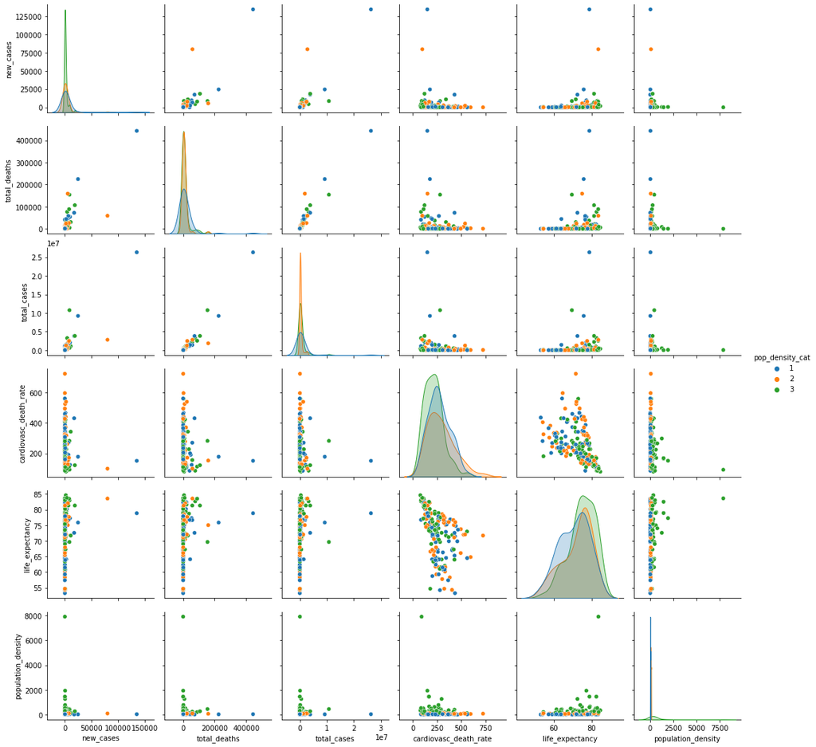

```python
sns.pairplot(covid_sum, hue='pop_density_cat',vars=['new_cases','total_deaths','total_cases', 'cardiovasc_death_rate','life_expectancy', 'population_density'] )
```

Looking at the pairplots coloring by population density category, there are no clear segmentations between three population density groups for COVID measurements.

- For each population density category, we didn't observe a correlation between life expectancy and Covid deaths.
- For each population density category, we didn't observe a correlation between population density and Covid cases.
- For each population density category, we didn't observe a correlation between cardiovascular death rate and Covid cases.

# Summary

We didn't identify any factors that are correlated with COVID cases/deaths. It turns out we cannot proove the following intial hypotheses based on current evidence:

1. Life Expectancy in a given region are negatively correlated to COVID Deaths.
2. Population density are positively correlated with total COVID cases.
3. New COVID cases are positively correlated with cardiovascular related deaths.

Next steps: 1) Consider other variables that could contribute to COVID cases/deaths (e.g. hospital beds). 2) Consider interation bewteen these variables.